# Qmec BaM

Felipe MENDEZ (INRAE, RiverLy) Novemeber 2024

# Acknowledgement

Felipe MENDEZ, Clara CHABRILLANGEAS, Benjamin RENARD, Jérôme LE COZ (INRAE, RiverLy and RECOVER). November 2024. Acknowledgement to Pascal MATTE (Enviroment Canada) and Daniel BOURGAULT (UQAR, Canada) for developing and sharing the code of [Qmec](https://codeocean.com/capsule/8881837/tree/v2),Bourgault and Matte (2022), as well as for their support and collaboration throughout this project.

# Introduction

[Qmec](https://doi.org/10.1029/2019JC015992) is a physically based, fully nonlinear, and nonstead reach-averaged river model to provide instantaneous freshwater discharge rates in tidal rivers using water level measurements alone at two tide gauge stations developed by Bourgault and Matte (2020).

The goal of `QmecBaM` is to incorporate the associated uncertainties during the calibration and simulation of discharge time series for a tidal river, achieved using Bayesian estimation. To achieve this, the package [BaM!](https://github.com/BaM-tools/BaM) will be applied.

## Installation

You can install the development version of QmecBaM from GitHub using the following command. Please note that the RBaM package developed by [Renard (2017)](https://hal.inrae.fr/hal-02606929) is also required to run this package.

```r
# Before first use, install RatingShiftHappens and RBaM packages ones and for all, following these commands:

# devtools::install_github("Felipemendezrios/QmecBaM")
# devtools::install_github('BaM-tools/RBaM')

library(QmecBaM)
```

## Case Saint Lawrence in Canada

In this example, the reach concerned covers the section between Neuville and Lauzon. Prior knowledge on geometric properties is required to run the model, as shown below:

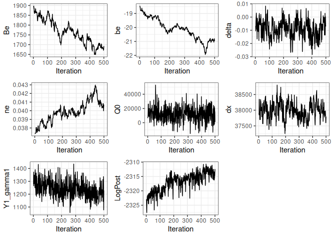

```r
# Prior knowledge
priors <- data.frame(
     # constant effective width of the rectangular channel
     Be = c(
          1500, # initial guess
          "LogNormal", # distribution
          log(1500), 0.1
     ), # parameters of the distribution
     # River bed elevation relative to a reference system
     be = c(
          -14.6915,
          "Gaussian",
          -14.6915, 2
     ),
     # Leveling error
     delta = c(
          0,
          "Gaussian",
          0, 0.02
     ),
     # effective friction coefficient
     ne = c(
          0.023,
          "LogNormal",
          log(0.023), 0.15
     ),
     # Initial discharge
     Q0 = c(
          12500,
          "Gaussian",
          12500, 10000
     ),
     # Distance between two gauge stations
     dx = c(
          38000,
          "Gaussian",
          38000, 250
     )
)

# Put in object for using RBaM package
Be <- RBaM::parameter(
     name = "Be",
     init = as.numeric(priors$Be[1]),
     prior.dist = priors$Be[2],
     prior.par = as.numeric(priors$Be[c(3, 4)])
)

be <- RBaM::parameter(
     name = "be",
     init = as.numeric(priors$be[1]),
     prior.dist = priors$be[2],
     prior.par = as.numeric(priors$be[c(3, 4)])
)

delta <- RBaM::parameter(
     name = "delta",
     init = as.numeric(priors$delta[1]),
     prior.dist = priors$delta[2],
     prior.par = as.numeric(priors$delta[c(3, 4)])
)

ne <- RBaM::parameter(
     name = "ne",
     init = as.numeric(priors$ne[1]),
     prior.dist = priors$ne[2],
     prior.par = as.numeric(priors$ne[c(3, 4)])
)

Q0 <- RBaM::parameter(
     name = "Q0",
     init = as.numeric(priors$Q0[1]),
     prior.dist = priors$Q0[2],
     prior.par = as.numeric(priors$Q0[c(3, 4)])
)

dx <- RBaM::parameter(
     name = "dx",
     init = as.numeric(priors$dx[1]),
     prior.dist = priors$dx[2],
     prior.par = as.numeric(priors$dx[c(3, 4)])
)

# Chart Datum of the upstream tide gauge
d1 <- -1.379
# Chart Datum of the downstream tide gauge
d2 <- -1.958
# temporal discretization of the model in seconds
dt_model <- 60

results_calibration <- Estimation_Qmec(
     CalibrationData = Saint_Laurent_F2,
     Be_object = Be,
     be_object = be,
     delta_object = delta,
     ne_object = ne,
     Q0_object = Q0,
     dx_object = dx,
     CD1 = d1,
     CD2 = d2,
     dt_model = dt_model,
     Nb_column_time_CalData = 7
)

# See MCMC results:
MCMC_exploration <- RBaM::tracePlot(results_calibration$MCMC)
gridExtra::grid.arrange(grobs = MCMC_exploration, ncol = 3)
```

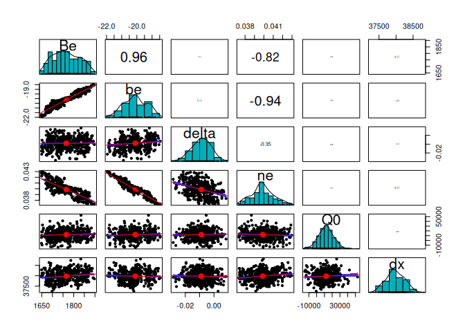

```r
# See scatterplot
psych::pairs.panels(
     results_calibration$MCMC[, -c(
          length(results_calibration$MCMC) - 1,
          length(results_calibration$MCMC)
     )],
     smooth = FALSE,
     lm = T,
     scale = T,
     method = "pearson", # correlation method
     hist.col = "#00AFBB",
     cor = T,
     ci = TRUE,
     density = TRUE, # show density plots
     ellipses = TRUE
) # show correlation ellipses
```

In the context of Bayesian estimation, it is necessary to check the prior and posterior distribution to ensure that the estimate is correct or diagnostic of the data or model.

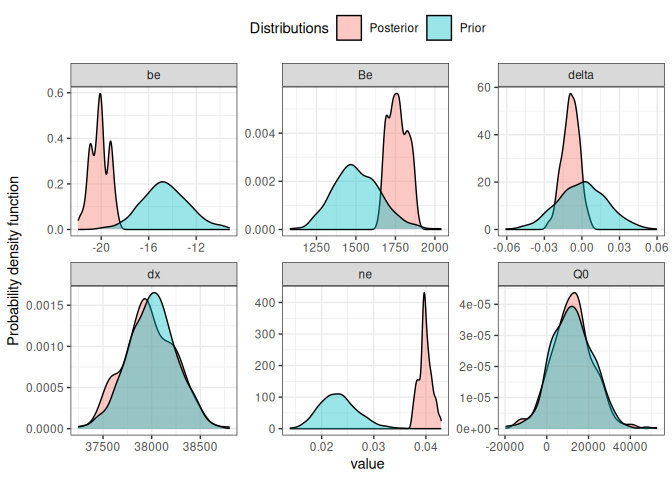

```r
Plot_prior_posterior(DF_prior_posterior = results_calibration$prior_vs_posterior)
```

The model parameters have been estimated so far. Let’s simulate the discharge time series.

```r
simulation_QMEC <- Prediction_Q_Qmec(
     CalibrationData = Saint_Laurent_F2,
     Model_object = results_calibration$Model_object,
     dt = 60 # seconds
)
```

Let’s plot the simulations with the associated uncertainties and the observations:

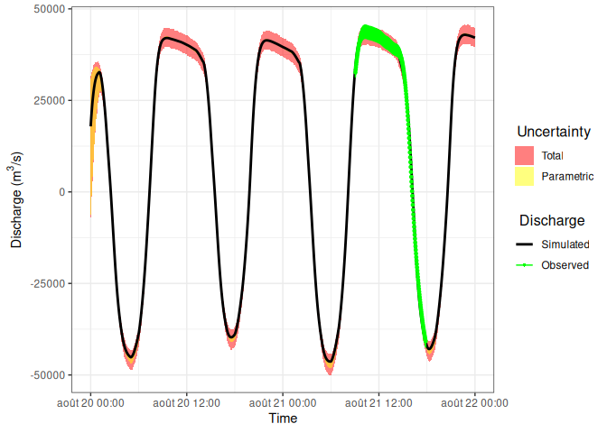

```r
Q_plot <- plot_Q_sim_Qmec(
     Q_observed = simulation_QMEC$Data_obs_plot,
     Q_simulated = simulation_QMEC$Qsim
)

Q_plot
```

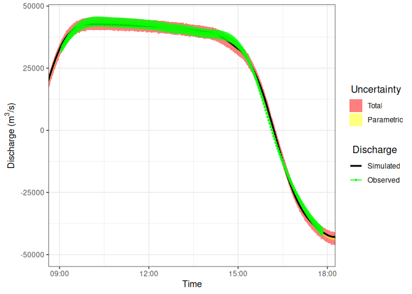

```r
# Zoom:
library(ggplot2)

Q_plot +
     coord_cartesian(x = c(
          min(Saint_Laurent_F2$date[which(Saint_Laurent_F2$Q != -9999)]),
          max(Saint_Laurent_F2$date[which(Saint_Laurent_F2$Q != -9999)])
     ))
```

Finally, it is also possible to plot the components of the 1D shallow water equation (pressure gradient, bottom friction and advection) to understand tidal dynamics:

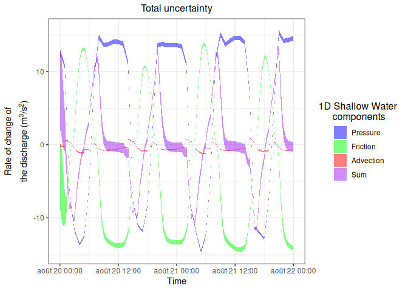

```r
SW_plot <- plot_shallow_water(
     pressure_SW = simulation_QMEC$pressure,
     friction_SW = simulation_QMEC$friction,
     advection_SW = simulation_QMEC$advection,
     MaxPostOnly = FALSE
)
# Total uncertainty:
SW_plot$TotalU
```

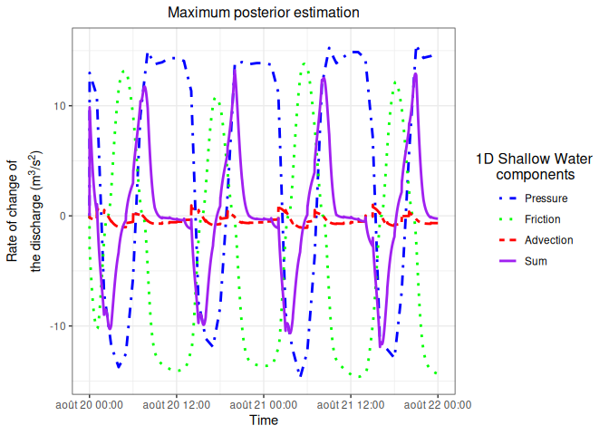

```r
# MaxPost:
SW_plot$MaxPost
```

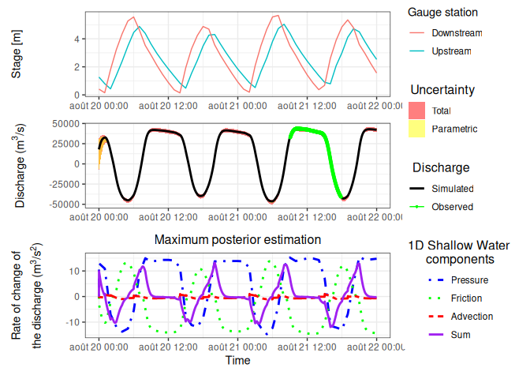

```r
# combine input and output data
input_stage_plot <- ggplot(Saint_Laurent_F2, aes(x = date)) +
     geom_line(aes(y = h1, col = "Upstream")) +
     geom_line(aes(y = h2, col = "Downstream")) +
     labs(
          x = "Time",
          y = "Stage [m]",
          col = "Gauge station"
     ) +
     theme_bw()

library(patchwork)

input_stage_plot +
     Q_plot +
     SW_plot$MaxPost +
     plot_layout(
          ncol = 1,
          guides = "collect",
          axis_titles = "collect"
     )
```

## Case Lower Seine in France

A second case study is proposed to test the tool and assess its applicability to other tidal rivers.

The Lower Seine is located between the Poses dam and the mouth of the Seine, where it flows into the English Channel. It lies within the Seine-Normandy basin in the Normandy region.

It was decided to test the tool on the section extending from the gauge station at Oissel upstream to Petite-Couronne downstream. The prior knowledge is specified here:

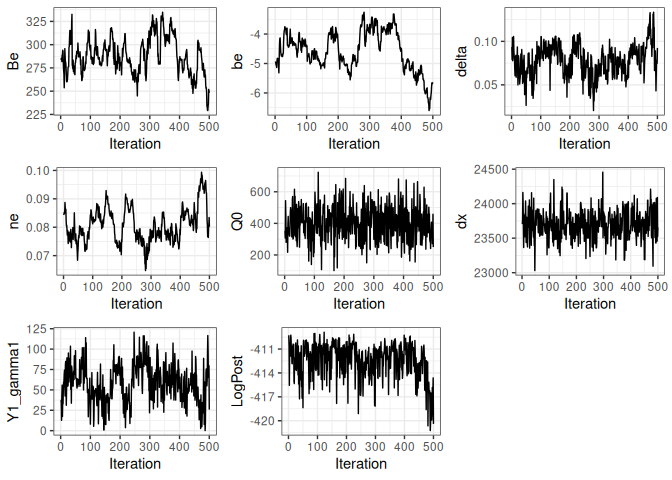

```r
# Prior knowledge
priors_LS <- data.frame(
     # constant effective width of the rectangular channel
     Be = c(
          150, # initial guess
          "LogNormal", # distribution
          log(150), 0.3
     ), # parameters of the distribution
     # River bed elevation relative to a reference system
     be = c(
          -5,
          "Gaussian",
          -5, 1
     ),
     # Leveling error
     delta = c(
          0,
          "Gaussian",
          0, 0.02
     ),
     # effective friction coefficient
     ne = c(
          0.025,
          "LogNormal",
          log(0.025), 0.15
     ),
     # Initial discharge
     Q0 = c(
          410,
          "Gaussian",
          410, 100
     ),
     # Distance between two gauge stations
     dx = c(
          23747,
          "Gaussian",
          23747, 200
     )
)

# Put in object for using RBaM package
Be_LS <- RBaM::parameter(
     name = "Be",
     init = as.numeric(priors_LS$Be[1]),
     prior.dist = priors_LS$Be[2],
     prior.par = as.numeric(priors_LS$Be[c(3, 4)])
)

be_LS <- RBaM::parameter(
     name = "be",
     init = as.numeric(priors_LS$be[1]),
     prior.dist = priors_LS$be[2],
     prior.par = as.numeric(priors_LS$be[c(3, 4)])
)

delta_LS <- RBaM::parameter(
     name = "delta",
     init = as.numeric(priors_LS$delta[1]),
     prior.dist = priors_LS$delta[2],
     prior.par = as.numeric(priors_LS$delta[c(3, 4)])
)

ne_LS <- RBaM::parameter(
     name = "ne",
     init = as.numeric(priors_LS$ne[1]),
     prior.dist = priors_LS$ne[2],
     prior.par = as.numeric(priors_LS$ne[c(3, 4)])
)

Q0_LS <- RBaM::parameter(
     name = "Q0",
     init = as.numeric(priors_LS$Q0[1]),
     prior.dist = priors_LS$Q0[2],
     prior.par = as.numeric(priors_LS$Q0[c(3, 4)])
)

dx_LS <- RBaM::parameter(
     name = "dx",
     init = as.numeric(priors_LS$dx[1]),
     prior.dist = priors_LS$dx[2],
     prior.par = as.numeric(priors_LS$dx[c(3, 4)])
)

# Chart Datum of the upstream tide gauge
d1_LS <- 0
# Chart Datum of the downstream tide gauge
d2_LS <- 0
# temporal discretization of the model in seconds
dt_model_LS <- 60

results_calibration_LS <- Estimation_Qmec(
     CalibrationData = Lower_Seine_Rouen,
     Be_object = Be_LS,
     be_object = be_LS,
     delta_object = delta_LS,
     ne_object = ne_LS,
     Q0_object = Q0_LS,
     dx_object = dx_LS,
     CD1 = d1_LS,
     CD2 = d2_LS,
     dt_model = dt_model_LS,
     Nb_column_time_CalData = 1
)

# See MCMC results:
MCMC_exploration_LS <- RBaM::tracePlot(results_calibration_LS$MCMC)
gridExtra::grid.arrange(grobs = MCMC_exploration_LS, ncol = 3)
```

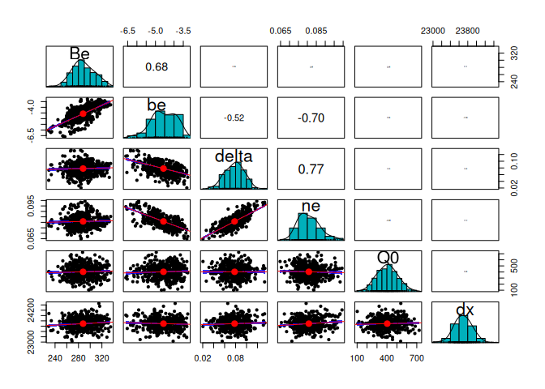

```r
# See scatterplot
psych::pairs.panels(
     results_calibration_LS$MCMC[, -c(
          length(results_calibration_LS$MCMC) - 1,
          length(results_calibration_LS$MCMC)
     )],
     smooth = FALSE,
     lm = T,
     scale = T,
     method = "pearson", # correlation method
     hist.col = "#00AFBB",
     cor = T,
     ci = TRUE,
     density = TRUE, # show density plots
     ellipses = TRUE
) # show correlation ellipses
```

Here a plot indicating the prior and posterior distribution:

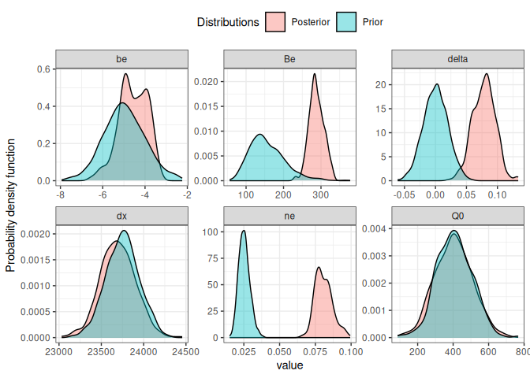

```r
Plot_prior_posterior(DF_prior_posterior = results_calibration_LS$prior_vs_posterior)
```

Here the discharge simulation:

```r
simulation_QMEC_LS <- Prediction_Q_Qmec(
     CalibrationData = Lower_Seine_Rouen,
     Model_object = results_calibration_LS$Model_object
)
```

Let’s plot the simulations with the associated uncertainties and the observations:

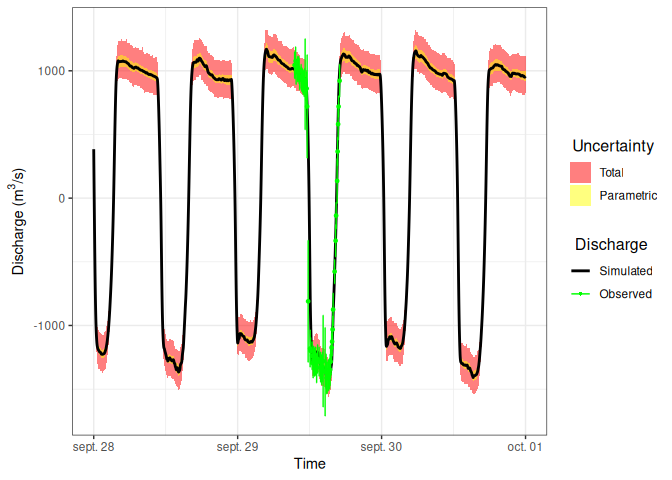

```r
Q_plot_LS <- plot_Q_sim_Qmec(
     Q_observed = simulation_QMEC_LS$Data_obs_plot,
     Q_simulated = simulation_QMEC_LS$Qsim
)

Q_plot_LS
```

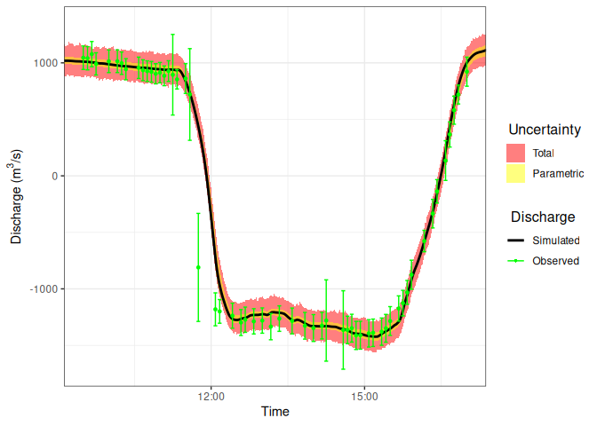

```r
# Zoom:
Q_plot_LS +
     coord_cartesian(x = c(
          min(Lower_Seine_Rouen$date[which(Lower_Seine_Rouen$Q != -9999)]),
          max(Lower_Seine_Rouen$date[which(Lower_Seine_Rouen$Q != -9999)])
     ))
```

Finally, it is also possible to plot the components of the 1D shallow water equation:

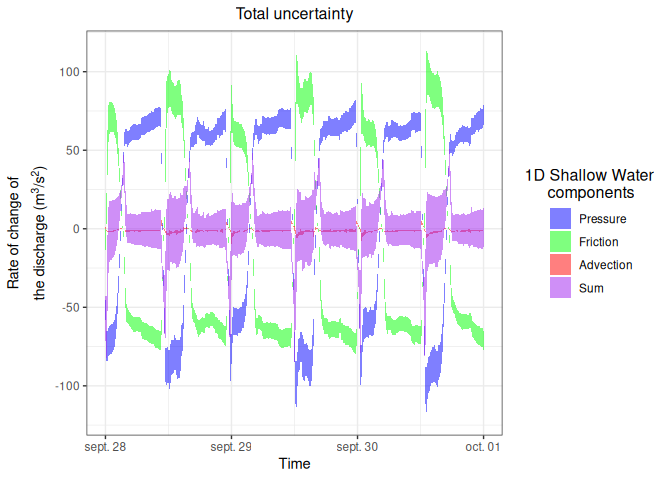

```r
SW_plot_LS <- plot_shallow_water(
     pressure_SW = simulation_QMEC_LS$pressure,
     friction_SW = simulation_QMEC_LS$friction,
     advection_SW = simulation_QMEC_LS$advection
)
# Total uncertainty:
SW_plot_LS$TotalU
```

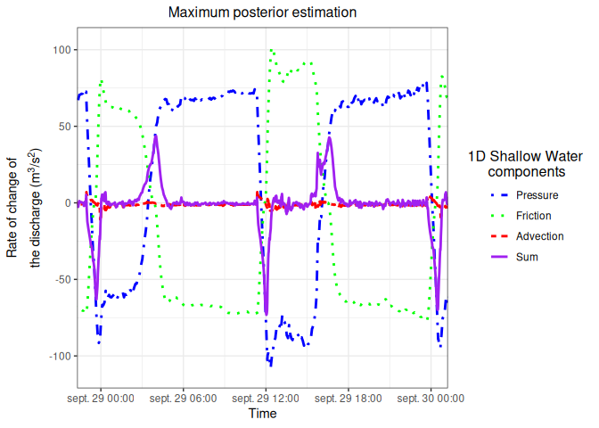

```r
# MaxPost:
SW_plot_LS$MaxPost + coord_cartesian(x = c(
     min(Lower_Seine_Rouen$date[which(Lower_Seine_Rouen$Q != -9999)]) - 10 * 3600,
     max(Lower_Seine_Rouen$date[which(Lower_Seine_Rouen$Q != -9999)]) + 7 * 3600
))
```

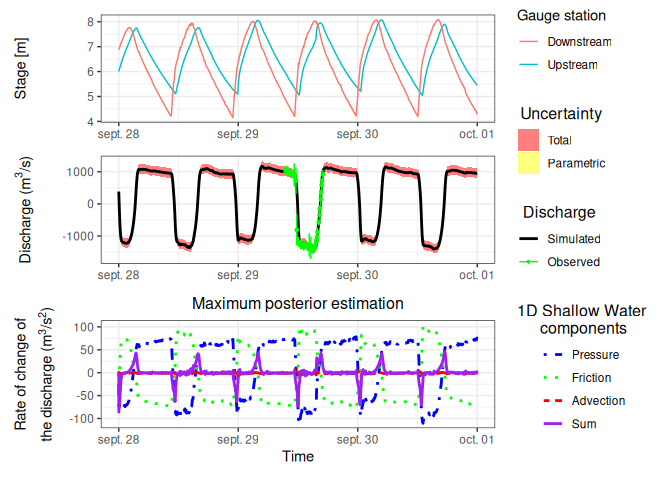

```r
# combine input and output data
input_stage_plot_LS <- ggplot(Lower_Seine_Rouen, aes(x = date)) +
     geom_line(aes(y = h1, col = "Upstream")) +
     geom_line(aes(y = h2, col = "Downstream")) +
     labs(
          x = "Time",
          y = "Stage [m]",
          col = "Gauge station"
     ) +
     theme_bw()

input_stage_plot_LS +
     Q_plot_LS +
     SW_plot_LS$MaxPost +
     plot_layout(
          ncol = 1,
          guides = "collect",
          axis_titles = "collect"
     )
```

Bourgault, Daniel, and Pascal Matte. 2020. “A Physically Based Method for Real-Time Monitoring of Tidal River Discharges From Water Level Observations, With an Application to the St. Lawrence River.” *Journal of Geophysical Research: Oceans* 125 (5): e2019JC015992. https://doi.org/10.1029/2019JC015992.

———. 2022. “Qmec : A Matlab Code to Compute Tidal River Discharge from Water Level.” Code Ocean. https://doi.org/10.24433/CO.7299598.V2.

Renard, Benjamin. 2017. “BaM ! (Bayesian Modeling): Un code de calcul pour l’estimation d’un modèle quelconque et son utilisation en prédiction.” {Report}. irstea.